# Stochastic surplus production model in continuous time (SPiCT)

Marta Cousido-Rocha and Francisco Izquierdo

2022-11-24

```r
#remotes::install_github("tokami/spict/spict", ref="fix130")
library(spict)
library(readxl)
```

# Preparing data: Biomass catch time series

Load data:

```r
load("data_SPiCT new CPUE & original CPUE& Catch & LFD.RData")
attach(objs)
```

Sum catch data across fleets:

```r
library(plyr)
catch<-ddply(catch_by_fleet, .(year,seas), summarize,  cat=sum(catch))
```

Weight-length relationship:

```r
len=as.numeric(substr(colnames(LFD_by_fleet)[-(1:6)], 2, 4))
a=2.459*10^{-5}
b=2.9667
wei=a*len^b
```

LFDs sum across fleets:

```r
library(dplyr)
LFD<-LFD_by_fleet %>% group_by(Yr, Seas) %>% summarise(across(everything(), list(sum)))
```

[output not shown]

```r
LFD=LFD[,-(3:6)]
```

Combine catch (numbers), LFDs and weight to obtain catch (tons):

```r
l=dim(LFD)[1]

resul=as.data.frame(LFD[,1:2])
resul$cat=rep(0,l)
for (i in 1:l){

  tot=sum(LFD[i,-c(1,2)])

  lfd=(LFD[i,-c(1,2)]*(catch[i,3]/tot))

  resul[i,3]=sum(lfd*wei)
}

# Sum across year:

catch_year=ddply(resul, .(Yr), summarize,  cat=sum(cat))
```

# Run 1: Year time series (Bayesian CPUE)

```r
ind1=which(unique(resul$Yr)==1972)
ind2=which(unique(resul$Yr)==2015)
inp1 <- list(timeC = unique(resul$Yr)[ind1:ind2], obsC =catch_year$cat[ind1:ind2],
            timeI = list(cpue_year_besag$year+0.5),
            obsI = list(cpue_year_besag$obs_sum))

inp1=check.inp(inp1)
```

The data can be plotted using the command:

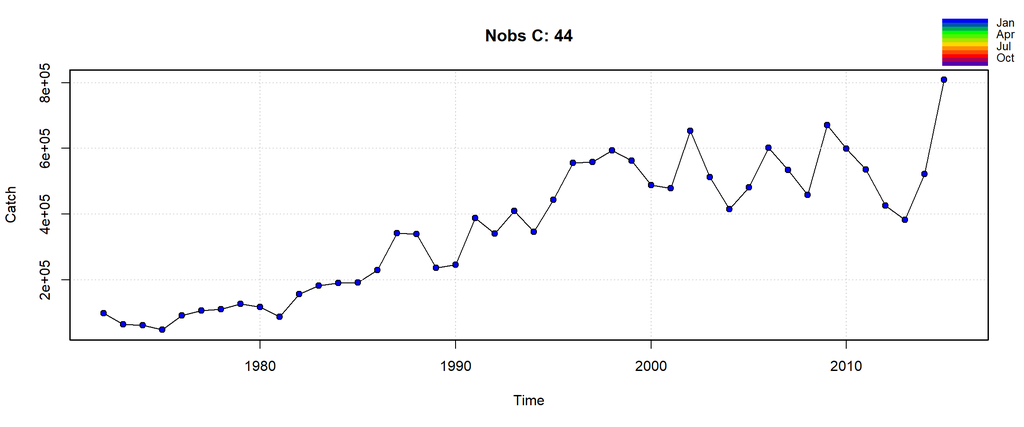

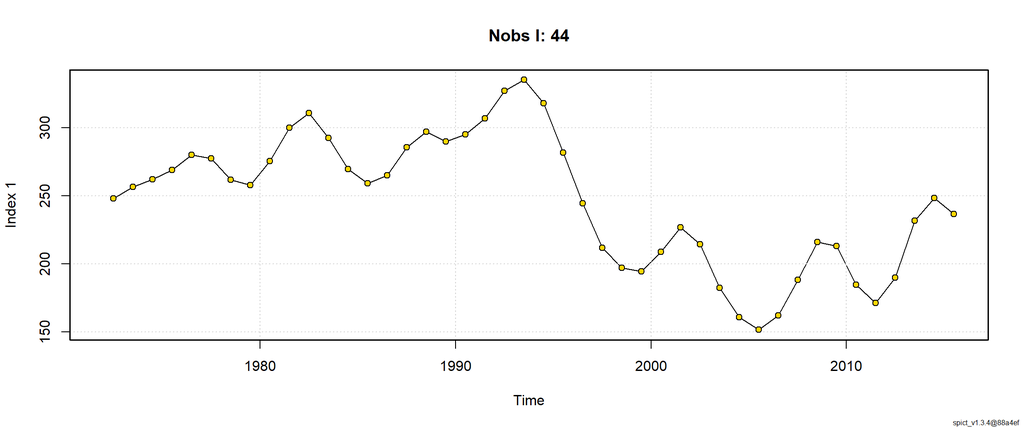

```r
source("functions.R")
source("plotting.R")
plotspict.data.adp(inp1)
```

The model is fitted to data by running:

```r
res1 <- fit.spict(inp1)
```

The results are summarized using:

```r
capture.output(summary(res1))
```

```
##  [1] "Convergence: 0  MSG: relative convergence (4)"
##  [2] "Objective function at optimum: -33.3516389"
##  [3] "Euler time step (years):  1/16 or 0.0625"
##  [4] "Nobs C: 44,  Nobs I1: 44"
##  [5] ""
##  [6] "Priors"
##  [7] "     logn  ~  dnorm[log(2), 2^2]"
##  [8] " logalpha  ~  dnorm[log(1), 2^2]"
##  [9] "  logbeta  ~  dnorm[log(1), 2^2]"
## [10] ""
## [11] "Model parameter estimates w 95% CI "
## [12] "            estimate        cilow        ciupp    log.est  "
## [13] " alpha  1.080256e-01 1.952700e-02 5.976103e-01 -2.2253875  "
## [14] " beta   3.514333e-01 1.195474e-01 1.033107e+00 -1.0457355  "
## [15] " r      4.440520e-01 1.793359e-01 1.099513e+00 -0.8118136  "
```

[output cut: 37 more lines]

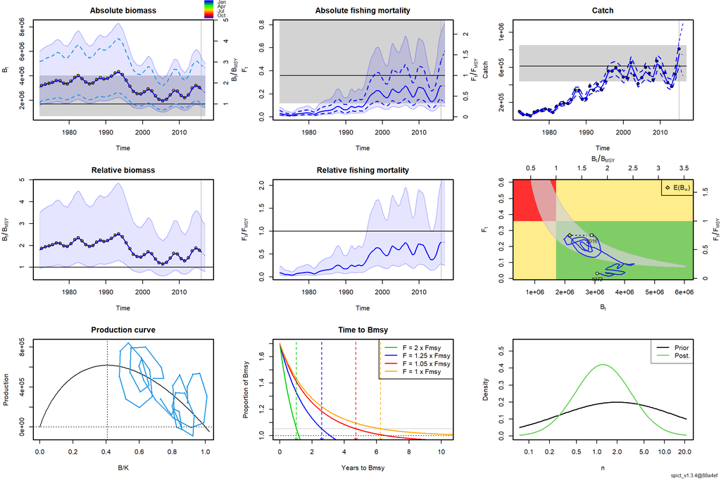

```r
plot(res1,CI = 0.9)
```

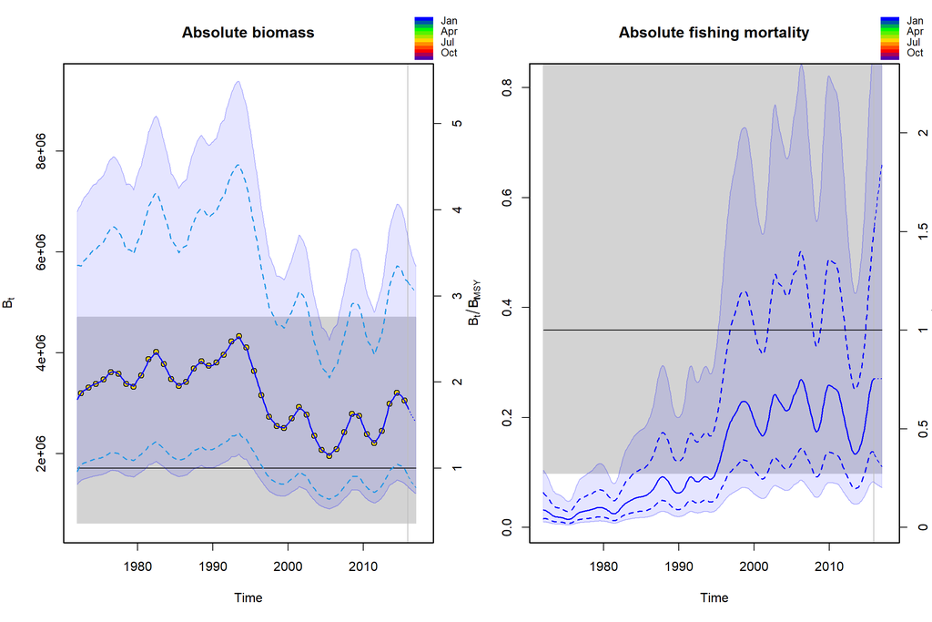

```r
par(mfcol=c(1,2))
plotspict.biomass(res1)
plotspict.f(res1)
```

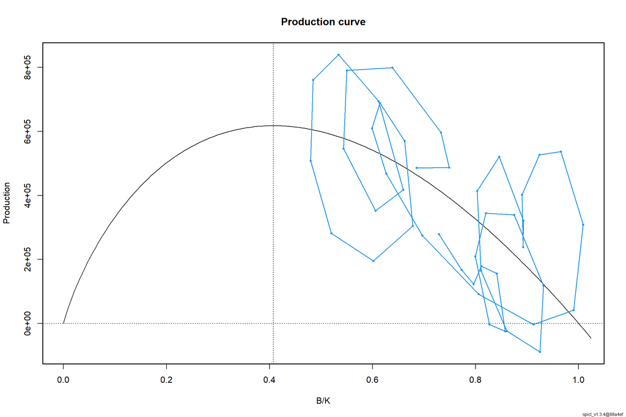

```r
par(mfcol=c(1,1))
plotspict.production(res1)
```

**Checklist for the acceptance of a SPiCT assessment**

```r
res1$opt$convergence
```

```
## [1] 0
```

```r
all(is.finite(res1$sd))
```

```
## [1] TRUE
```

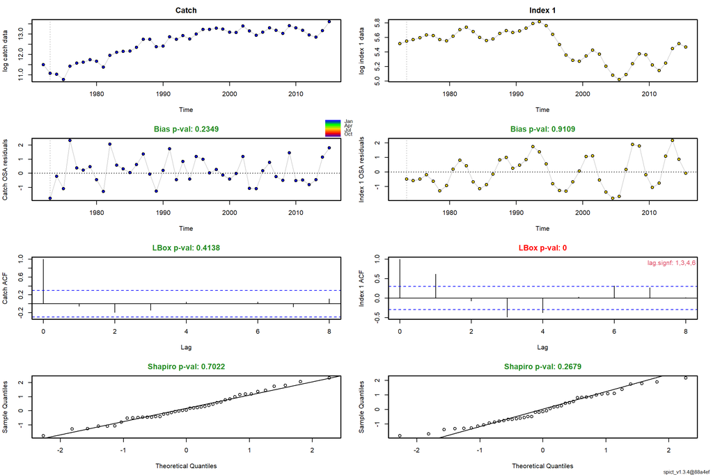

```r
r1 <- calc.osa.resid(res1)
plotspict.diagnostic(r1,lag.max =8)
```

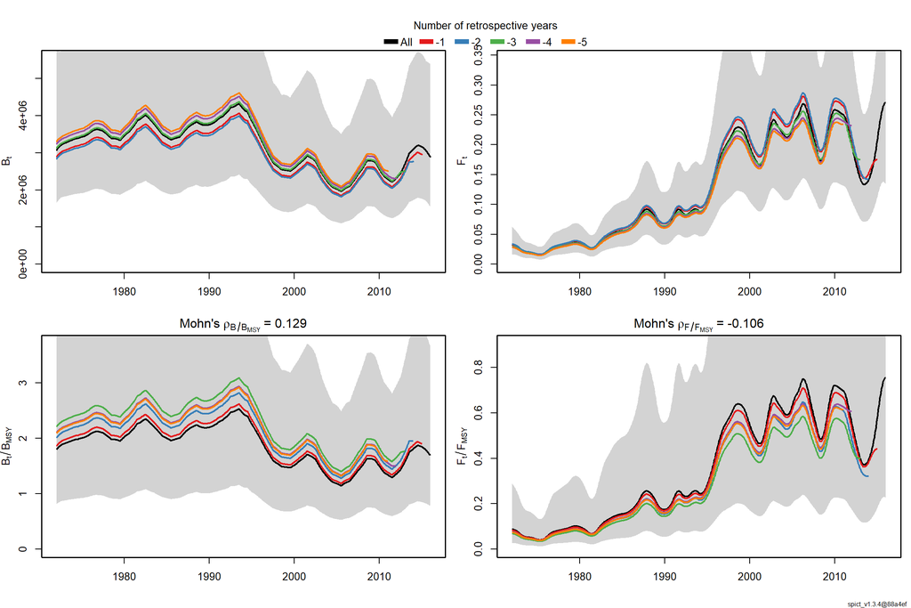

```
##      FFmsy      BBmsy
## -0.1055146  0.1287746
```

```r
r1<- res1
rep1=retro(r1, nretroyear=5)
plotspict.retro(rep1)
```

Confidence intervals of $F/F_{msy}$ and $B/B_{msy}$ estimates.

```r
fit=res1

get.par("logFmFmsy", fit, exp=TRUE, CI = 0.9)
```

```
##                 ll       est       ul        sd        cv
## logFmFmsy 0.275648 0.7539283 2.062079 0.6117095 0.6736551
```

```r
get.par("logBmBmsy", fit, exp=TRUE, CI = 0.9)
```

```
##                  ll      est       ul        sd        cv
## logBmBmsy 0.8871948 1.692279 3.227936 0.3925984 0.4082237
```

I also compute AIC value:

```r
get.AIC(res1)
```

```
## [1] -50.70328
```

Save biomass/F trends:

```r
bio1=get.par("logB", res1, exp = TRUE)[seq(1,length(inp1$time),by=16),2]
F1=get.par("logFs", res1, exp = TRUE)[seq(1,length(inp1$time),by=16),2]

Bio_spict$bio_year_besag=bio1
F_spict$F_year_besag=F1
```

# Run 2: Year time series (Original CPUE)

```r
ind1=which(unique(resul$Yr)==1972)
ind2=which(unique(resul$Yr)==2015)
inp2 <- list(timeC = unique(resul$Yr)[ind1:ind2], obsC =catch_year$cat[ind1:ind2],
            timeI = list(cpue_year_original$year+0.5),
            obsI = list(cpue_year_original$obs_sum))
inp2=check.inp(inp2)
```

The data can be plotted using the command:

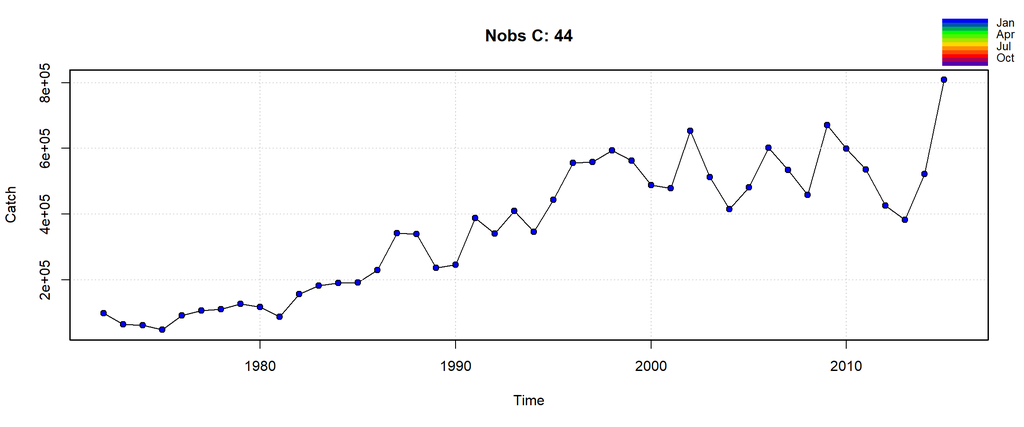

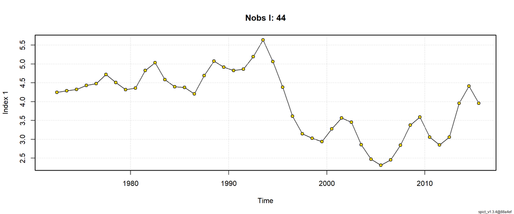

```r
plotspict.data.adp(inp2)
```

The model is fitted to data by running:

```r
res2 <- fit.spict(inp2)
```

The results are summarized using:

```r
capture.output(summary(res2))
```

```
##  [1] "Convergence: 0  MSG: relative convergence (4)"
##  [2] "Objective function at optimum: -26.0611785"
##  [3] "Euler time step (years):  1/16 or 0.0625"
##  [4] "Nobs C: 44,  Nobs I1: 44"
##  [5] ""
##  [6] "Priors"
##  [7] "     logn  ~  dnorm[log(2), 2^2]"
##  [8] " logalpha  ~  dnorm[log(1), 2^2]"
##  [9] "  logbeta  ~  dnorm[log(1), 2^2]"
## [10] ""
## [11] "Model parameter estimates w 95% CI "
## [12] "            estimate        cilow        ciupp     log.est  "
## [13] " alpha  1.159827e-01 2.045090e-02 6.577715e-01  -2.1543139  "
## [14] " beta   3.229180e-01 9.935440e-02 1.049536e+00  -1.1303570  "
## [15] " r      6.412799e-01 2.613123e-01 1.573749e+00  -0.4442892  "
```

[output cut: 37 more lines]

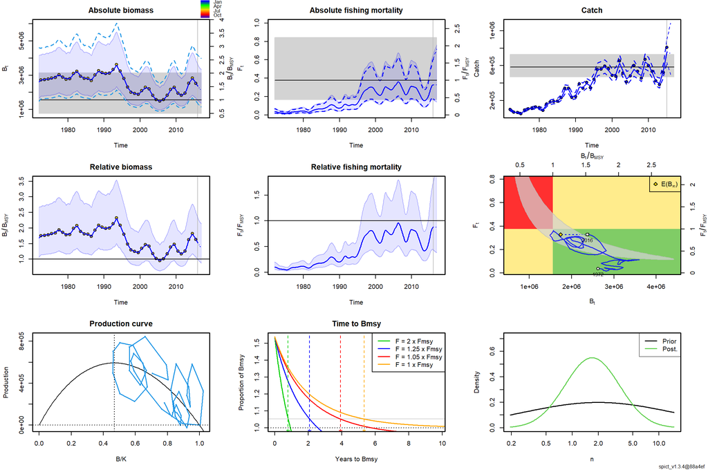

```r
plot(res2,CI = 0.9)
```

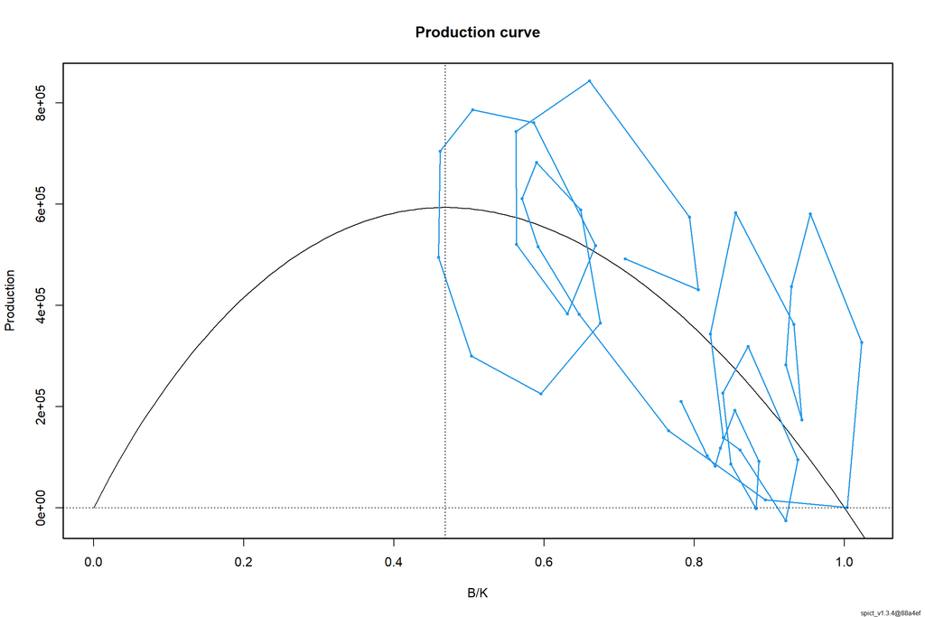

```r
par(mfcol=c(1,1))
plotspict.production(res2)
```

**Checklist for the acceptance of a SPiCT assessment**

```r
res2$opt$convergence
```

```
## [1] 0
```

```r
all(is.finite(res2$sd))
```

```
## [1] TRUE
```

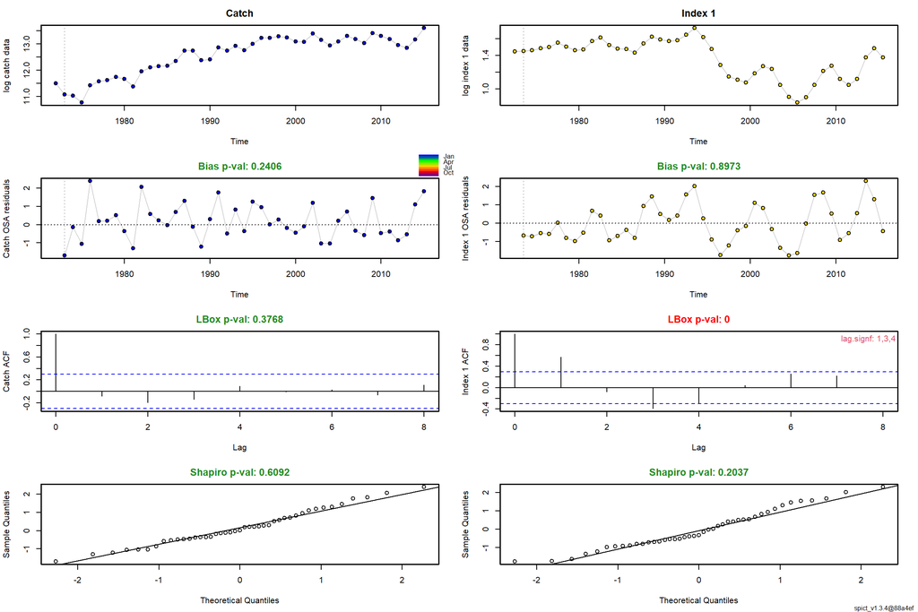

```r
r2 <- calc.osa.resid(res2)
plotspict.diagnostic(r2,lag.max =8)
```

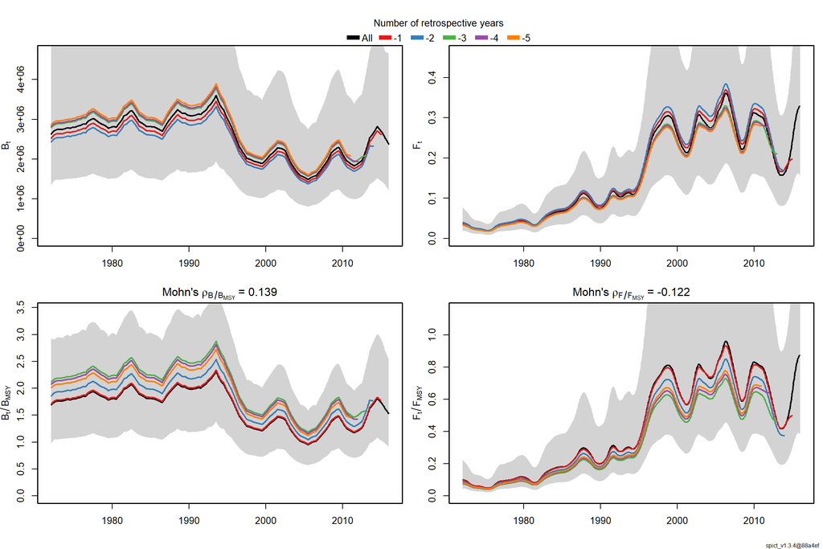

```
##      FFmsy      BBmsy
## -0.1215888  0.1389264
```

```r
r2<- res2
rep1=retro(r2, nretroyear=5)
plotspict.retro(rep1)
```

Confidence intervals of $F/F_{msy}$ and $B/B_{msy}$ estimates.

```r
fit=res2

get.par("logFmFmsy", fit, exp=TRUE, CI = 0.9)
```

```
##                 ll       est      ul        sd        cv
## logFmFmsy 0.435835 0.8733559 1.75009 0.4225783 0.4421645
```

```r
get.par("logBmBmsy", fit, exp=TRUE, CI = 0.9)
```

```
##                 ll     est       ul        sd        cv
## logBmBmsy 0.995993 1.52607 2.338259 0.2594218 0.2638484
```

I also compute AIC value:

```r
get.AIC(res2)
```

```
## [1] -36.12236
```

Save biomass/F trends:

```r
bio2=get.par("logB", res2, exp = TRUE)[seq(1,length(inp2$time),by=16),2]
F2=get.par("logFs", res2, exp = TRUE)[seq(1,length(inp2$time),by=16),2]

Bio_spict$bio_year_original=bio2
F_spict$F_year_original=F2
```

# Run 3: Seas catch and CPUE time series (Bayesian CPUE)

```r
ind=which(resul[,2]==1)
resul[ind,2]=0
ind1=which(resul[,2]==4)
resul[ind1,2]=0.25
ind2=which(resul[,2]==7)
resul[ind2,2]=0.5
ind3=which(resul[,2]==10)
resul[ind3,2]=0.75
seq_I=rep(c(0,0.25,0.5,0.75),length(unique(cpue_seas_besag$year)))
ind1=min(which(resul[,1]==1972))
ind2=max(which(resul[,1]==2015))
inp3 <- list(timeC = resul[ind1:ind2,1]+resul[ind1:ind2,2], obsC = resul[ind1:ind2,3],
            timeI = list(cpue_seas_besag$year+seq_I),
            obsI = list(cpue_seas_besag$obs))

inp3=check.inp(inp3)
```

The data can be plotted using the command:

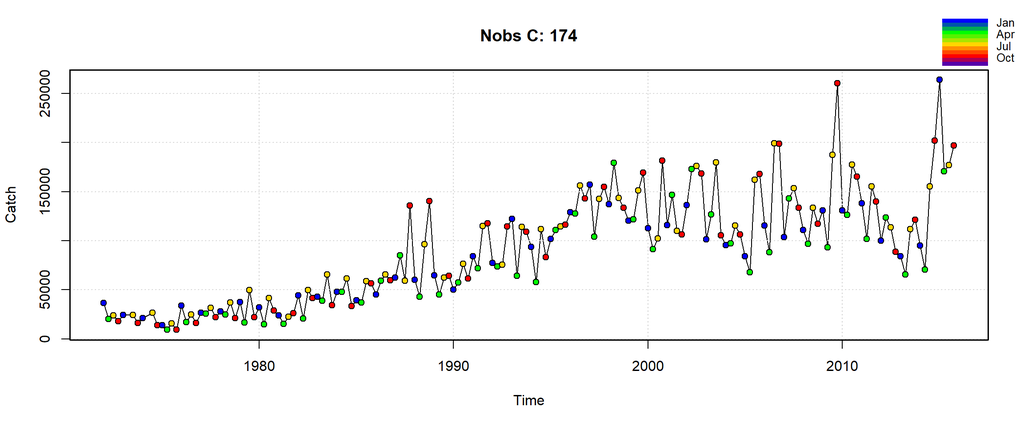

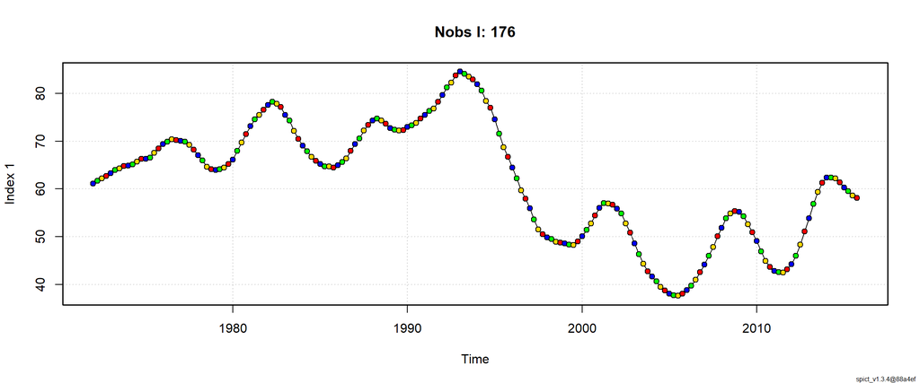

```r
plotspict.data.adp(inp3)
```

The model is fitted to data by running:

```r
res3 <- fit.spict(inp3)
```

The results are summarized using:

```r
capture.output(summary(res3))
```

```
##  [1] "Convergence: 0  MSG: relative convergence (4)"
##  [2] "Objective function at optimum: -372.6925097"
##  [3] "Euler time step (years):  1/16 or 0.0625"
##  [4] "Nobs C: 174,  Nobs I1: 176"
##  [5] ""
##  [6] "Priors"
##  [7] "     logn  ~  dnorm[log(2), 2^2]"
##  [8] " logalpha  ~  dnorm[log(1), 2^2]"
##  [9] "  logbeta  ~  dnorm[log(1), 2^2]"
## [10] ""
## [11] "Model parameter estimates w 95% CI "
## [12] "            estimate        cilow        ciupp     log.est  "
## [13] " alpha  2.759910e-02 6.972200e-03 1.092501e-01  -3.5899722  "
## [14] " beta   9.499477e-01 6.964890e-01 1.295642e+00  -0.0513483  "
## [15] " r      2.558753e-01 1.276412e-01 5.129389e-01  -1.3630653  "
```

[output cut: 40 more lines]

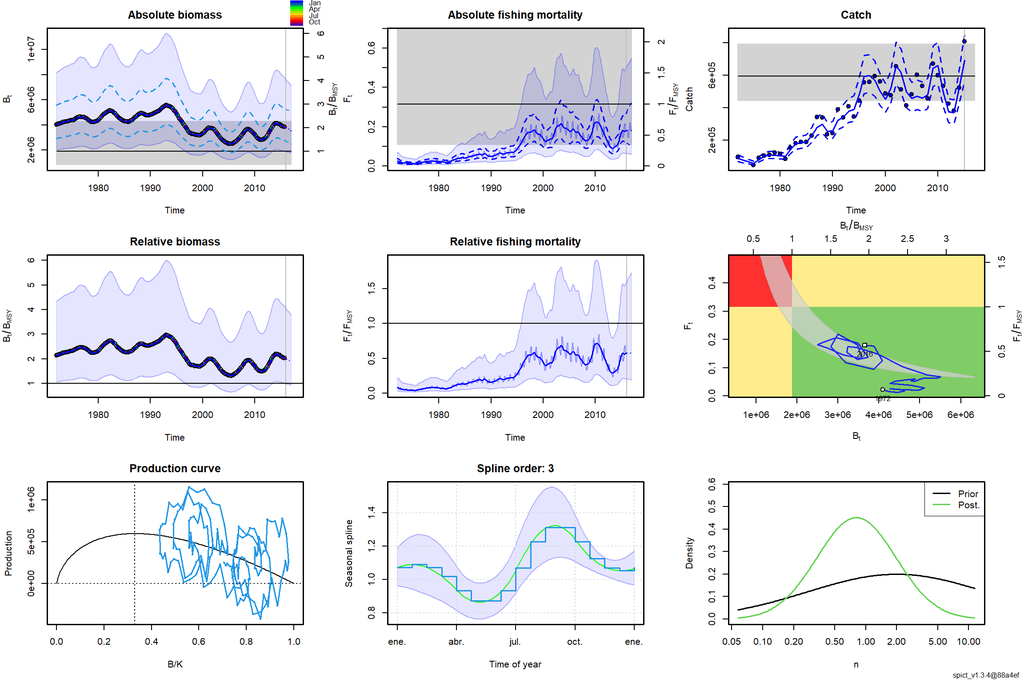

```r
plot(res3,CI = 0.9)
```

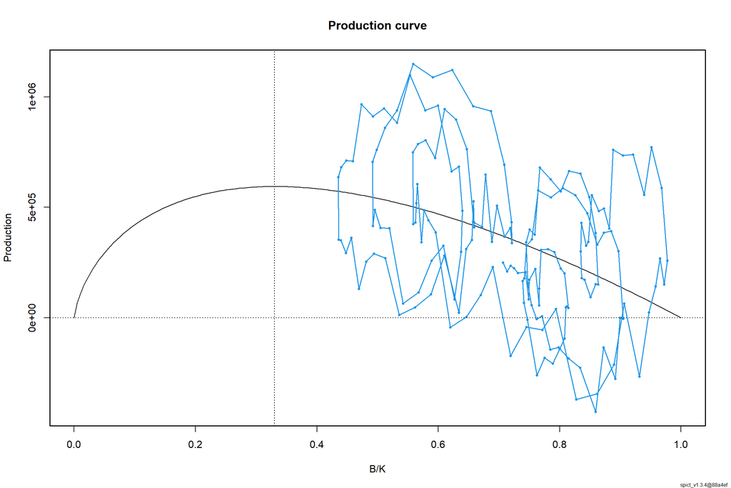

```r
par(mfcol=c(1,1))
plotspict.production(res3)
```

**Checklist for the acceptance of a SPiCT assessment**

```r
res3$opt$convergence
```

```
## [1] 0
```

```r
all(is.finite(res3$sd))
```

```
## [1] TRUE
```

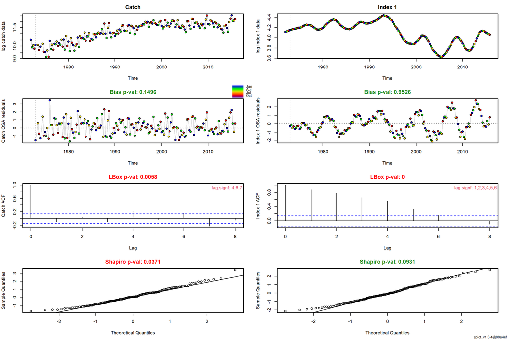

```r
r3 <- calc.osa.resid(res3)
plotspict.diagnostic(r3,lag.max =8)
```

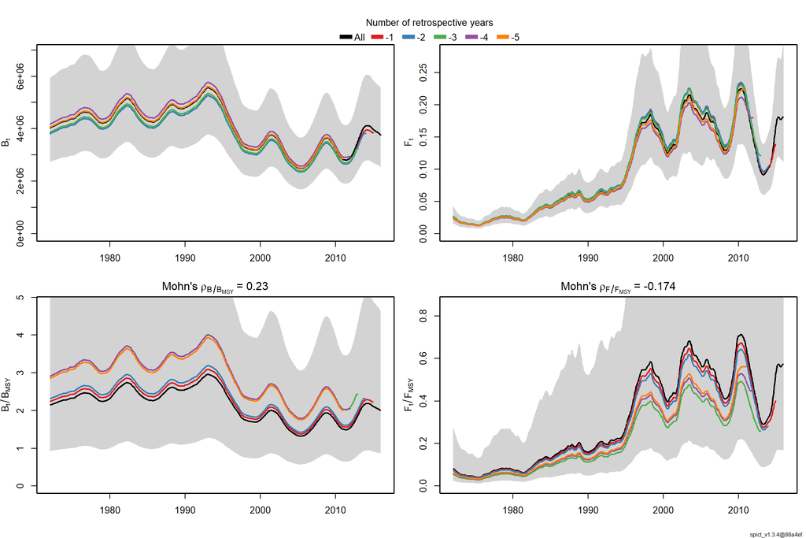

```
##      FFmsy      BBmsy
## -0.1736152  0.2297999
```

```r
r3<- res3
rep3=retro(r3, nretroyear=5)
plotspict.retro(rep3)
```

Confidence intervals of $F/F_{msy}$ and $B/B_{msy}$ estimates.

```r
fit=res3

get.par("logFmFmsy", fit, exp=TRUE, CI = 0.9)
```

```
##                  ll       est       ul        sd        cv
## logFmFmsy 0.2035498 0.5688443 1.589703 0.6247947 0.6910319
```

```r
get.par("logBmBmsy", fit, exp=TRUE, CI = 0.9)
```

```
##                  ll      est       ul        sd        cv
## logBmBmsy 0.9885327 1.998742 4.041311 0.4280328 0.4484073
```

I also compute AIC value:

```r
get.AIC(res3)
```

```
## [1] -723.385
```

Save biomass/F trends:

```r
bio3=get.par("logB", res3, exp = TRUE)[seq(1,length(inp3$time),by=4),2]
F3=get.par("logFs", res3, exp = TRUE)[seq(1,length(inp3$time),by=4),2]

Bio_spict$bio_seas_besag=bio3
F_spict$F_seas_besag=F3
```

# Run 4: Seas catch and CPUE time series (Original CPUE)

```r
ind=which(resul[,2]==1)
resul[ind,2]=0
ind1=which(resul[,2]==4)
resul[ind1,2]=0.25
ind2=which(resul[,2]==7)
resul[ind2,2]=0.5
ind3=which(resul[,2]==10)
resul[ind3,2]=0.75
seq_I=rep(c(0,0.25,0.5,0.75),length(unique(cpue_seas_besag$year)))
ind1=min(which(resul[,1]==1972))
ind2=max(which(resul[,1]==2015))
inp4 <- list(timeC = resul[ind1:ind2,1]+resul[ind1:ind2,2], obsC = resul[ind1:ind2,3],
            timeI = list(cpue_seas_original$year+seq_I),
            obsI = list(cpue_seas_original$obs))

inp4=check.inp(inp4)
```

The data can be plotted using the command:

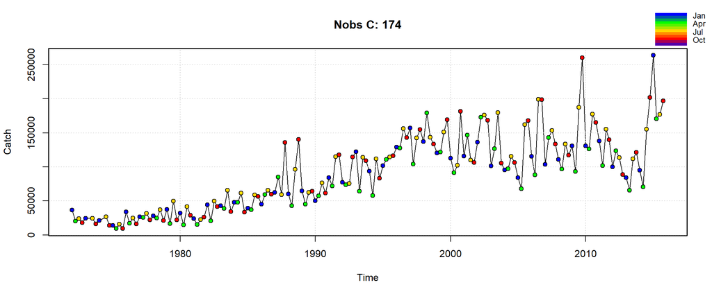

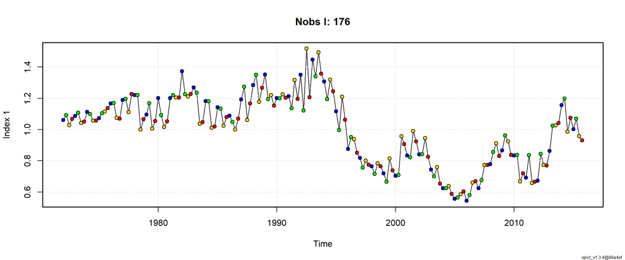

```r
plotspict.data.adp(inp4)
```

The model is fitted to data by running:

```r
res4 <- fit.spict(inp4)
```

The results are summarized using:

```r
capture.output(summary(res4))
```

```
##  [1] "Convergence: 0  MSG: relative convergence (4)"
##  [2] "Objective function at optimum: -132.2097614"
##  [3] "Euler time step (years):  1/16 or 0.0625"
##  [4] "Nobs C: 174,  Nobs I1: 176"
##  [5] ""
##  [6] "Priors"
##  [7] "     logn  ~  dnorm[log(2), 2^2]"
##  [8] " logalpha  ~  dnorm[log(1), 2^2]"
##  [9] "  logbeta  ~  dnorm[log(1), 2^2]"
## [10] ""
## [11] "Model parameter estimates w 95% CI "
## [12] "            estimate        cilow        ciupp     log.est  "
## [13] " alpha  4.852830e-01 3.192225e-01 7.377288e-01  -0.7230230  "
## [14] " beta   9.305174e-01 6.564414e-01 1.319025e+00  -0.0720145  "
## [15] " r      8.427549e-01 3.818788e-01 1.859846e+00  -0.1710791  "
```

[output cut: 40 more lines]

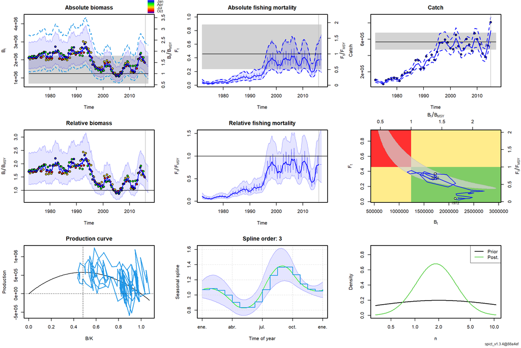

```r
plot(res4,CI = 0.9)
```

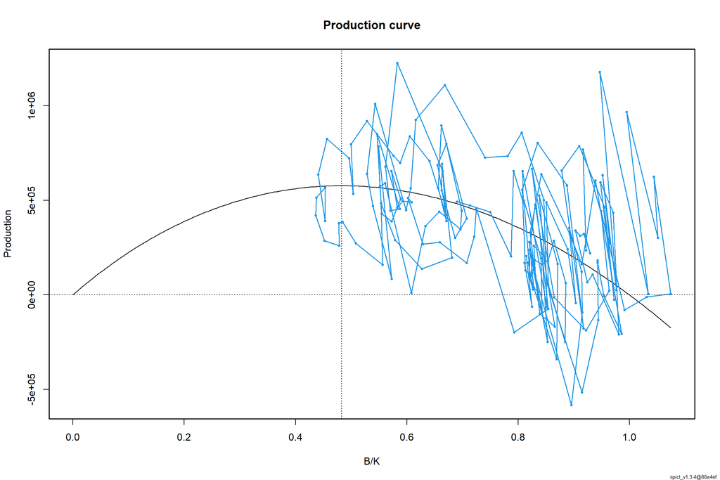

```r
par(mfcol=c(1,1))
plotspict.production(res4)
```

**Checklist for the acceptance of a SPiCT assessment**

```r
res4$opt$convergence
```

```
## [1] 0
```

```r
all(is.finite(res4$sd))
```

```
## [1] TRUE
```

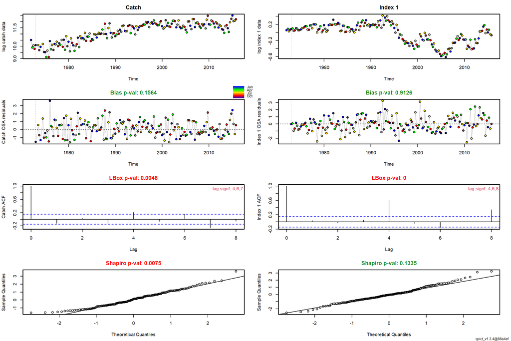

```r
r4 <- calc.osa.resid(res4)
plotspict.diagnostic(r4,lag.max =8)
```

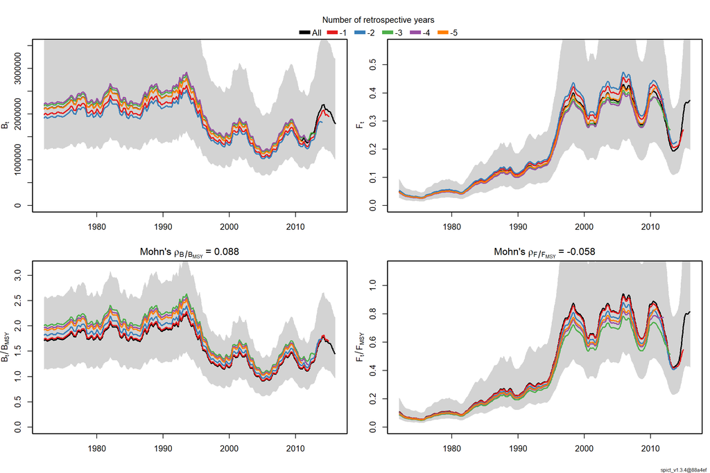

```
##       FFmsy       BBmsy
## -0.05777369  0.08811312
```

```r
r4<- res4
rep4=retro(r4, nretroyear=5)
plotspict.retro(rep4)
```

Confidence intervals of $F/F_{msy}$ and $B/B_{msy}$ estimates.

```r
fit=res4

get.par("logFmFmsy", fit, exp=TRUE, CI = 0.9)
```

```
##                  ll       est       ul        sd        cv
## logFmFmsy 0.4612212 0.8052046 1.405734 0.3387649 0.3487206
```

```r
get.par("logBmBmsy", fit, exp=TRUE, CI = 0.9)
```

```
##                 ll      est       ul        sd       cv
## logBmBmsy 1.031024 1.446307 2.028861 0.2057696 0.207967
```

I also compute AIC value:

```r
get.AIC(res4)
```

```
## [1] -242.4195
```

Save biomass/F trends:

```r
bio4=get.par("logB", res4, exp = TRUE)[seq(1,length(inp4$time),by=4),2]
F4=get.par("logFs", res4, exp = TRUE)[seq(1,length(inp4$time),by=4),2]

Bio_spict$bio_seas_original=bio4
F_spict$F_seas_original=F4
```

```r
save(Bio_spict, file="Bio_spict.RData")
save(F_spict, file="F_spict.RData")
```

# Comparing to SS

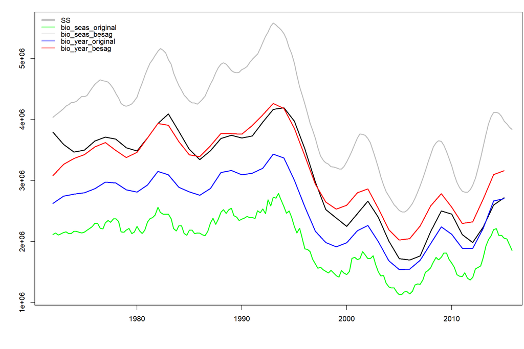

```r
load("data_SPiCT new CPUE & original CPUE & Bio.RData")
bio=objs$bio
a=c(Bio_spict$bio_seas_original,Bio_spict$bio_seas_besag,Bio_spict$bio_year_original,
    Bio_spict$bio_year_besag,bio$bio)
ind1=min(which(bio$year==1972))
ind2=max(which(bio$year==2015))

par(mar = c(5, 4, 1.4, 0.2))
plot(bio$year[ind1:ind2],bio$bio[ind1:ind2], col="black", type="l",lwd=2, ylim=c(min(a),max(a)),xlab="",ylab="")

ind1=min(which(resul[,1]==1972))
ind2=max(which(resul[,1]==2015))
ind3=max(which(names(Bio_spict$bio_seas_original)=="2015.75"))
lines(as.numeric(names(Bio_spict$bio_seas_original)[1:ind3]), Bio_spict$bio_seas_original[1:ind3],col="green",lwd=2)


ind3=max(which(names(Bio_spict$bio_seas_besag)=="2015.75"))
lines(as.numeric(names(Bio_spict$bio_seas_besag)[1:ind3]),Bio_spict$bio_seas_besag[1:ind3], col="grey",lwd=2)

ind1=which(unique(resul$Yr)==1972)
ind2=which(unique(resul$Yr)==2015)
ind3=which(names(Bio_spict$bio_year_besag)=="2015")
lines(unique(resul$Yr)[ind1:ind2],Bio_spict$bio_year_original[1:ind3], col="blue",lwd=2)
lines(unique(resul$Yr)[ind1:ind2],Bio_spict$bio_year_besag[1:ind3], col="red",lwd=2)

legend("topleft", legend=c("SS","bio_seas_original", "bio_seas_besag","bio_year_original","bio_year_besag"),
       col=c("black","green","grey","blue","red"), cex=1, lty=1, bty='n',y.intersp=0.8)
```